# Arjun EDA file

**Nagarjuna Lokaraju** **(Loan Default - Machine Learning Pipelines)**

Exploratory Data Analysis

**Here the main aim is understand more about the data. I will explore the data using the following steps.**

[output not shown]

(1) Importing the Data

```python
# Importing Libraries

import pandas as pd
import numpy as np
import matplotlib.pyplot as plt
%matplotlib inline
import seaborn as sns
```

```python
# Displaying all the columns of the Dataframe

pd.pandas.set_option('display.max_columns', None)

# Displaying all the rows of the Dataframe

# pd.pandas.set_option('display.max_rows', None)
```

```python
dataset = pd.read_csv("/Users/lokaraju/JOBS/Loan Project /LoanDataset.csv")
```

```python
#printing the top 5 records

dataset.head(5)
```

```
Button(description='Toggle Pandas/Lux', layout=Layout(top='5px', width='140px'), style=ButtonStyle())
```

```
Output()
```

```python
# printing the shape of dataset with rows and cloumns

print(dataset.shape)
```

```
(148670, 32)
```

(2) Describing the data

**Explaining the Dataset**

Loan Defaulters Dataset contains 148670 rows and 32 features. The dependent feature here would be the Status which has binary outcome either 0 or 1 i.e., the person would default or not. The data has various numerical discrete and continuous variables as well as the categorical variables. Here we are going to be very comprehensive in understanding each and every variable and how are the impacting the status. detailed Feature enginnering.

**Basic Statistics Dataset**

```python
dataset.describe()
```

```
Button(description='Toggle Pandas/Lux', layout=Layout(top='5px', width='140px'), style=ButtonStyle())
```

```
Output()
```

**Data types and non-null values**

```python
#Finding the data type and also the non null values of the columns in the dataset.

dataset.info()
```

```
<class 'lux.core.frame.LuxDataFrame'>
RangeIndex: 148670 entries, 0 to 148669
Data columns (total 32 columns):
 #   Column                     Non-Null Count   Dtype
---  ------                     --------------   -----
 0   ID                         148670 non-null  int64
 1   loan_limit                 145326 non-null  object
 2   Gender                     148670 non-null  object
 3   approv_in_adv              147762 non-null  object
 4   loan_type                  148670 non-null  object
 5   loan_purpose               148536 non-null  object
 6   Credit_Worthiness          148670 non-null  object
 7   open_credit                148670 non-null  object
 8   business_or_commercial     148670 non-null  object
 9   loan_amount                148670 non-null  int64
```

[output cut: 24 more lines]

(3) Missing Values

**List of features which has missing values**

```python
features_with_na=[features
                  for features in dataset.columns
                  if dataset[features].isnull().sum()>1]
features_with_na
```

```
['loan_limit',
 'approv_in_adv',
 'loan_purpose',
 'rate_of_interest',
 'Interest_rate_spread',
 'Upfront_charges',
 'term',
 'Neg_ammortization',
 'property_value',
 'income',
 'age',
 'submission_of_application',
 'dtir1']
```

**Feature name and percentage of missing values in each feature**

```python
for features in features_with_na:
    print(features,  round(dataset[features].isnull().mean(),4), '% missing value')
```

```
loan_limit 0.0225 % missing value
approv_in_adv 0.0061 % missing value
loan_purpose 0.0009 % missing value
rate_of_interest 0.2451 % missing value
Interest_rate_spread 0.2464 % missing value
Upfront_charges 0.2666 % missing value
term 0.0003 % missing value
Neg_ammortization 0.0008 % missing value
property_value 0.1016 % missing value
income 0.0615 % missing value
age 0.0013 % missing value
submission_of_application 0.0013 % missing value
dtir1 0.1622 % missing value
```

```python
#Importing Missingno library


#!pip -q install missingno

import missingno as msno
```

**Displaying Missing Values**

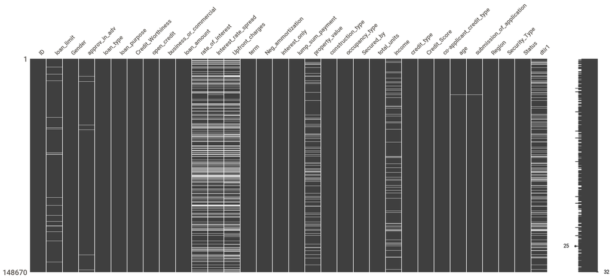

```python
msno.matrix(dataset)
plt.show()
```

**Checking the relation between missing values and dependent variable**

This is to see how the missing values are actually affecting the dependent variable.

Here iam creating a copy of the dataset so that if there are any changes made to the dataset that wouldnt affect the overall original data

There is a possibility of inverse proportionality, where we can say there are lot of missing values as a result the loan amount is low. There is a possibility it can create an impact.

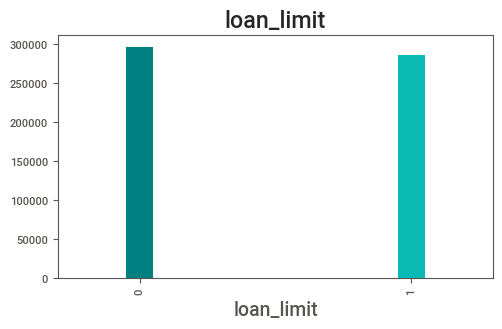

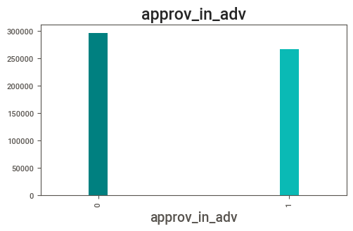

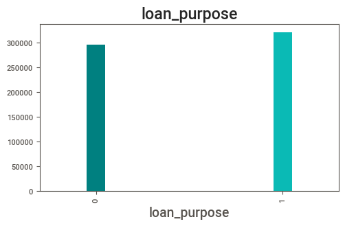

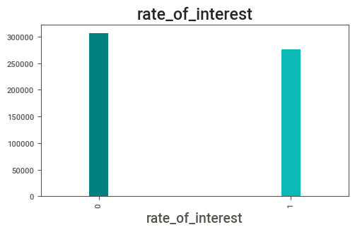

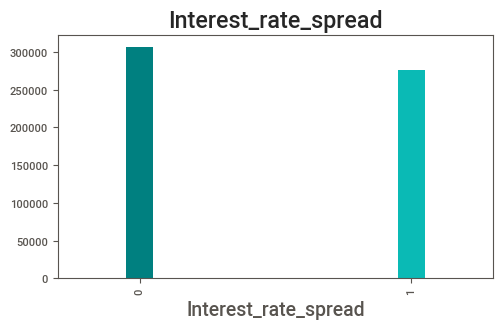

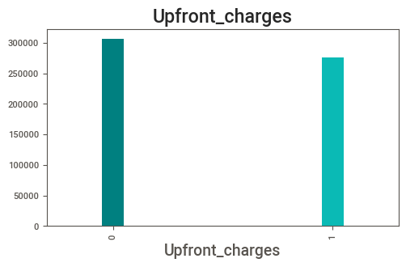

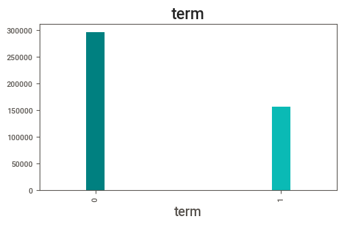

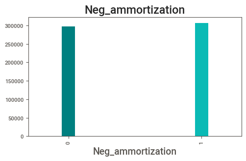

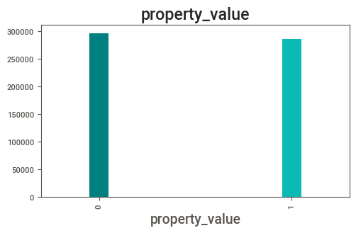

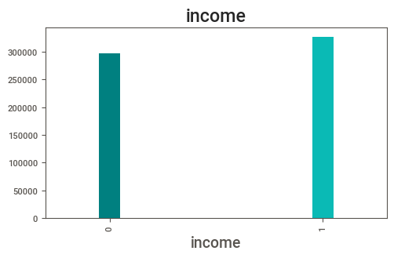

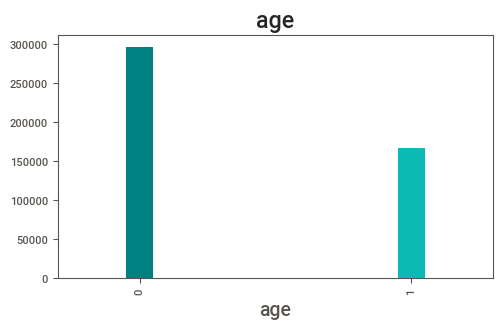

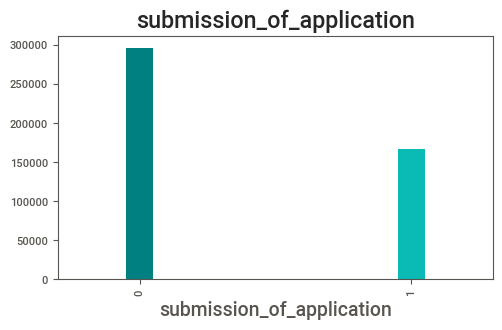

[1 more figures not shown]

```python
for feature in features_with_na:
    data = dataset.copy()


    data[feature] = np.where(data[feature].isnull(),1,0)

    #com
    plt.figure(figsize=(5, 3))
    data.groupby(feature)['loan_amount'].median().plot.bar(width=0.1, color=['Teal', '#0ABAB5'])
    plt.title(feature)
    plt.show()
```

**Observation**

Here majority of the graphs we can see that the non null values are higher than the null values "1". There are instances where both are almost the same. In some cases 1 value is more, there is a possibility that the higher median loan amount.

Features such as loan purpose, income, dtir1 has the null value higher which might be th epossible reason for creating a increase in the median of the loan amount. We need to replace it with an appropriate values. This we shall do in the feature engineering part.

(4) Numerical Features

**List of Numerical variables**

##### Here we are finding as to how many features are numerical variables in the datasetCreating the list of features from the features in the dataset where the dataset type is not object

```python
numerical_features = [feature
                      for feature in dataset.columns
                      if dataset[feature].dtypes != 'O']

print("Total number of Numerical Features are", len(numerical_features) )
```

```
Total number of Numerical Features are 11
```

**Displaying numerical feature**

```python
numerical_features
```

```
['ID',
 'loan_amount',
 'rate_of_interest',
 'Interest_rate_spread',
 'Upfront_charges',
 'term',
 'property_value',
 'income',
 'Credit_Score',
 'Status',
 'dtir1']
```

```python
dataset[numerical_features].head(5)
```

```
Button(description='Toggle Pandas/Lux', layout=Layout(top='5px', width='140px'), style=ButtonStyle())
```

```
Output()
```

```python
dataset[numerical_features].info()
```

```
<class 'lux.core.frame.LuxDataFrame'>
RangeIndex: 148670 entries, 0 to 148669
Data columns (total 11 columns):
 #   Column                Non-Null Count   Dtype
---  ------                --------------   -----
 0   ID                    148670 non-null  int64
 1   loan_amount           148670 non-null  int64
 2   rate_of_interest      112231 non-null  float64
 3   Interest_rate_spread  112031 non-null  float64
 4   Upfront_charges       109028 non-null  float64
 5   term                  148629 non-null  float64
 6   property_value        133572 non-null  float64
 7   income                139520 non-null  float64
 8   Credit_Score          148670 non-null  int64
 9   Status                148670 non-null  int64
 10  dtir1                 124549 non-null  float64
dtypes: float64(7), int64(4)
memory usage: 12.5 MB
```

**Observation**

We have created a list of numerical features. Here there are discrete numerical features as well as continuous features.

(5) Distribution of Numerical Freatures

#### In numerical features there are discrete variables and continuous variables. We caanot differentiate the discrete variables and continuous variables based on the datatype i.r., int64 for integer and float for continuous. There is a possibility of the data that the numerical features may have a decimal and 0 at the end which is still considered as a float by the system.

**Discrete Variables**

From the explanation above i would like to continue further. Here i would like to see if there categories are more than the personally set threshold limit of 30 features I would consider it as a continious variable and not discrete.

```python
discrete_features = [feature
                     for feature in numerical_features
                    if len(dataset[feature].unique())<30
                     and feature not in ['Id'] ]
```

```python
#count unique values in each column
dataset[numerical_features].nunique()
```

```
Button(description='Toggle Pandas/Lux', layout=Layout(top='5px', width='140px'), style=ButtonStyle())
```

```
Output()
```

```python
discrete_features
```

```
['term', 'Status']
```

```python
dataset[discrete_features].head(6)
```

```
Button(description='Toggle Pandas/Lux', layout=Layout(top='5px', width='140px'), style=ButtonStyle())
```

```
Output()
```

```python
# fining the relationship between the discrete variables
```

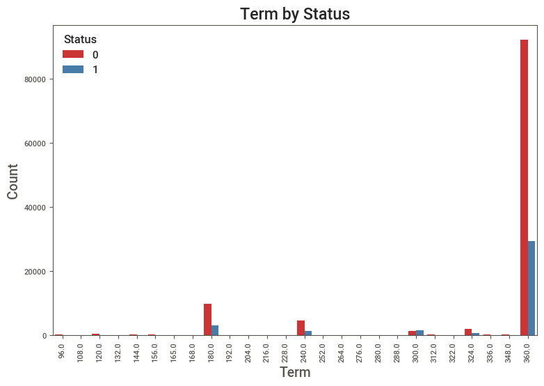

```python
sns.countplot(x='term', data=data, hue='Status')
plt.xlabel('Term')
plt.ylabel('Count')
plt.title('Term by Status')
plt.xticks(rotation=90)
plt.show()
```

**Observation**

From the status and term we see that the majority of the loan applications are for term of 360 days and the defaulters and non defaulters. The other popular terms are at 180 , 240, 300, 324 days. The others have been insignificant in comparision to these.

**Continuous Variables**

```python
continous_features = [feature
                     for feature in numerical_features
                    if feature not in discrete_features + ['ID']]
```

```python
continous_features
```

```
['loan_amount',
 'rate_of_interest',
 'Interest_rate_spread',
 'Upfront_charges',
 'property_value',
 'income',
 'Credit_Score',
 'dtir1']
```

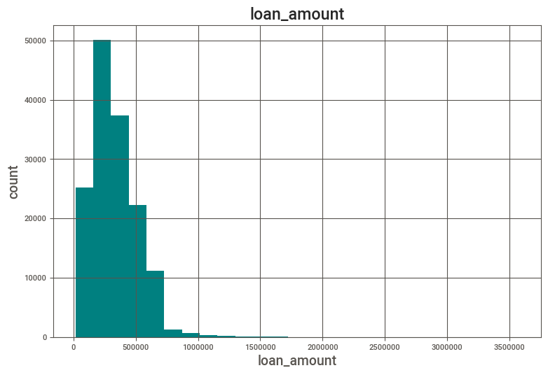

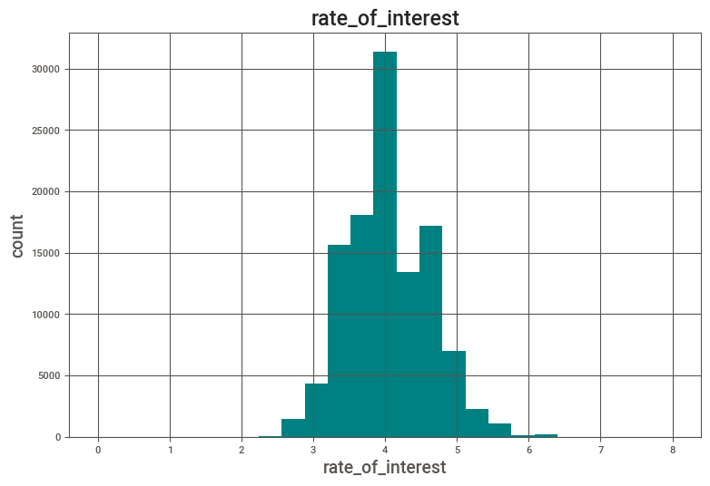

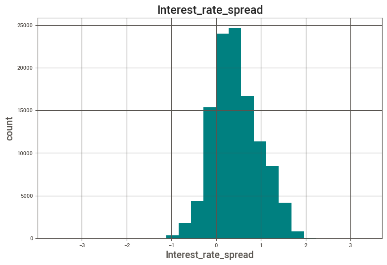

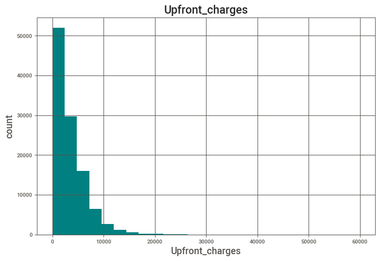

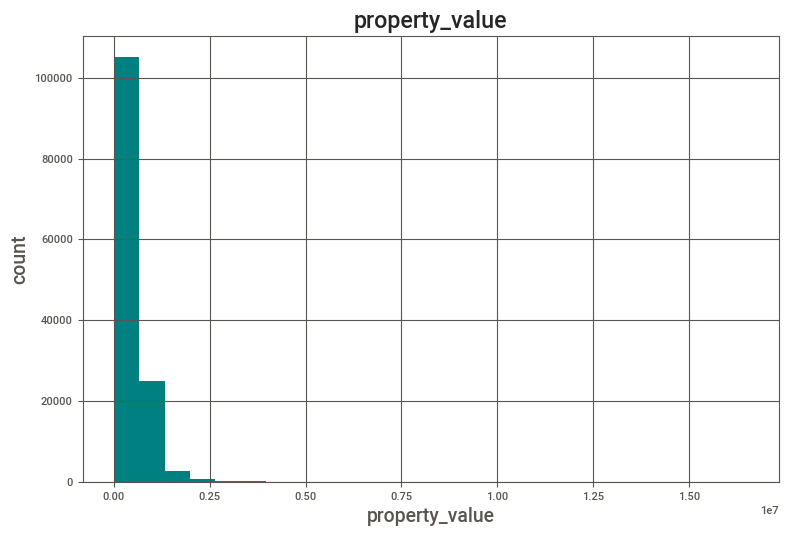

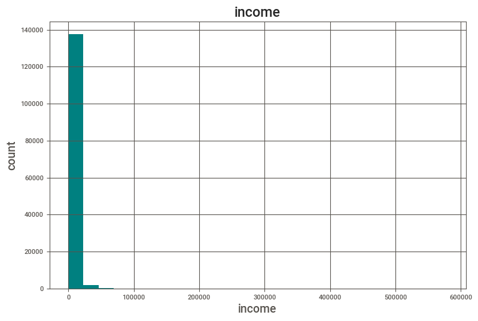

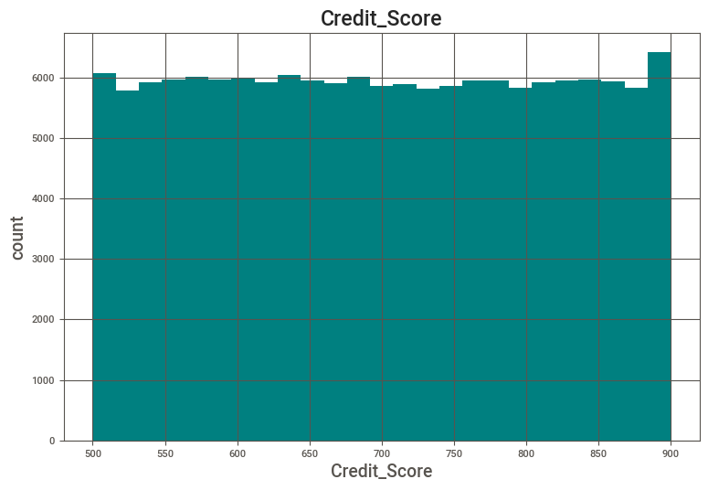

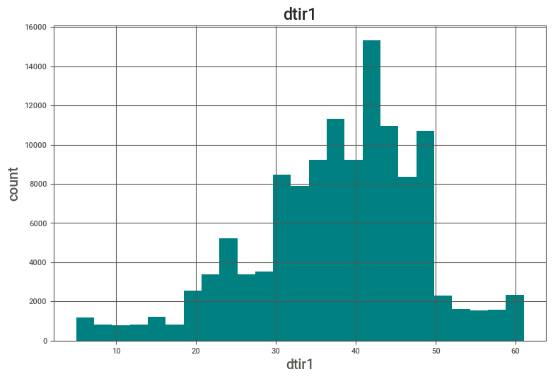

```python
#analysing the continuous variables , we can create histogram to understand the skewness , data normality

for feature in continous_features:
    data = dataset.copy()
    data[feature].hist(bins=25, color = 'Teal')

    #plt.figure(figsize=(5, 3))
    #data.groupby(feature)['loan_amount'].median().plot.bar(width=0.1, color=['Teal', '#0ABAB5'])

    plt.xlabel(feature)
    plt.ylabel("count")
    plt.title(feature)
    plt.show()
```

**Observation**

**Logarithmic Trasnformation**

Whenever the data is not distributed properly or skewed, we actually transform that into normal distribution.

For the data i am using the dataset.copy this is to make sure that changes made to data are not reflecting directly on the actual dataset. In simple words This copy is made to ensure that any modifications made within the loop do not affect the original dataset. Since we need to perform Logarithmic Transformation.

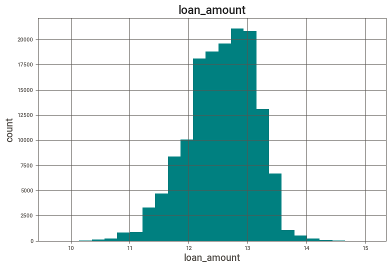

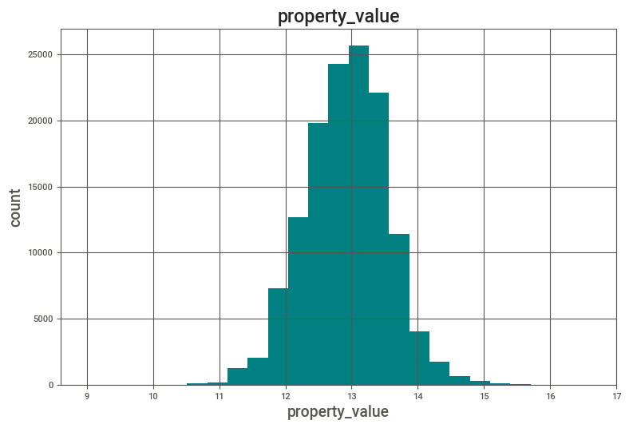

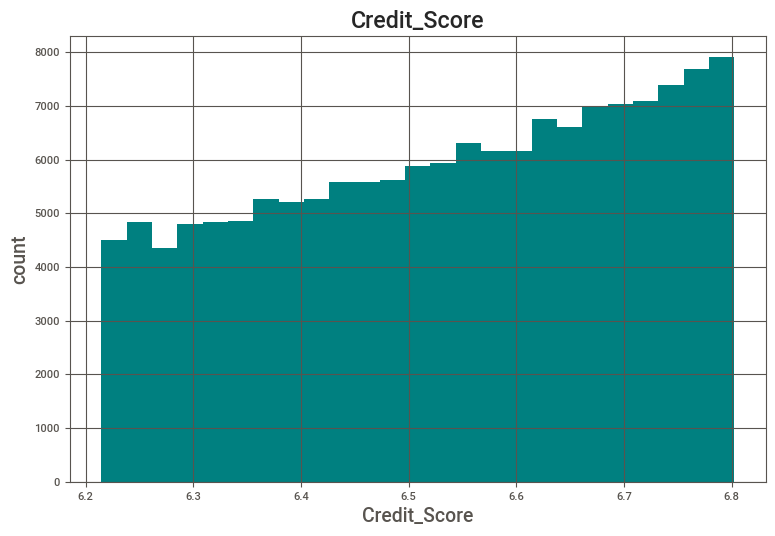

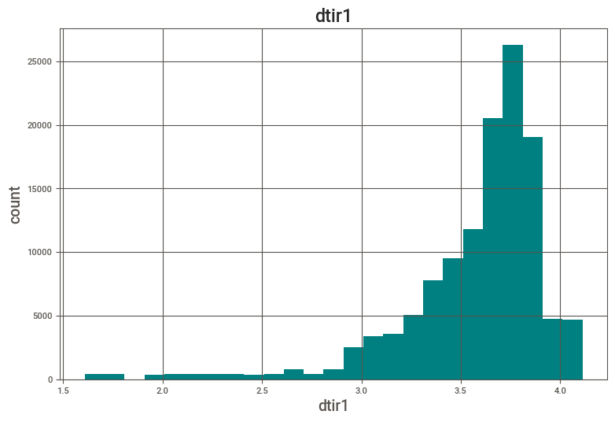

```python
# applying log normal transformation

for feature in continous_features:
    data = dataset.copy()
    if 0 in data[feature].unique():
        pass
    else:
        data[feature]=np.log(data[feature])
        data[feature].hist(bins=25, color = 'Teal')
        plt.xlabel(feature)
        plt.ylabel("count")
        plt.title(feature)
        plt.show()
```

**Why Logarithmic Transformation ?**

The log-normal transformation is used when the data is right-skewed (positively skewed) and the variability increases exponentially as the values increase. In other words, the log-normal distribution is a skewed distribution in which the logarithm of the data follows a normal distribution. This transformation can help to stabilize the variance and make the data more symmetric.

The main reasons to consider log-normal transformation include:

1. **Stabilizing Variance:** In some data sets, the variability tends to increase with the magnitude of the values, leading to heteroscedasticity. Applying a log-normal transformation compresses the large values, reducing the range and bringing the variability under control.
2. **Normalization:** The log-normal transformation can convert data that does not follow a normal distribution into one that approximately follows a normal distribution. Many statistical methods assume or work best with normally distributed data. Transforming the data to approximate normality can make these methods more appropriate and reliable.
3. **Linearizing Relationships:** In some cases, the relationships between variables might not be linear in the original scale. However, after applying a log-normal transformation, the relationships might become linear or more interpretable.
4. **Interpretable Multiplicative Effects:** In some fields, such as economics or finance, log-normal transformations are used because they allow the effects of predictors to be multiplicative rather than additive. For example, a 10% change in the predictor corresponds to a certain percentage change in the outcome, regardless of the initial value.

However, it's important to be cautious when using log-normal transformations. Some points to consider are:

1. **Outliers:** Log-normal transformations are sensitive to extreme values (outliers). Extreme values in the original data can result in a long tail in the log-transformed data.
2. **Interpretation:** When you apply a log-normal transformation, the interpretation of the results needs to consider the transformation. Back-transforming results into the original scale may require using antilogarithms.
3. **Applicability:** Log-normal transformations are suitable for data with positive values. It's not appropriate for data that can have negative or zero values, as taking the logarithm of zero or negative values is not defined.

In summary, the log-normal transformation is a useful technique to consider when dealing with skewed data and heteroscedasticity. It can stabilize variance, linearize relationships, and make the data more amenable to statistical analyses. However, as with any transformation, it should be applied judiciously, with careful consideration of the data characteristics and the goals of the analysis.

**Observation**

The purpose of this code seems to be to perform a natural logarithm transformation on the continuous numerical features in the dataset but only for those features that do not contain any zero values. If a feature contains zero values, it is skipped (due to the pass statement), and no transformation is applied.

Performing a logarithmic transformation on continuous data that contains zero is generally not recommended because the natural logarithm is undefined for non-positive values (including zero). Taking the logarithm of zero or a negative number results in a mathematical error.

In many practical scenarios, data that contains zero values can be quite common in real-world datasets. For example, consider a dataset with measurements of some quantity where zero represents a meaningful value (e.g., the number of customers who made no purchases in a month). In such cases, applying a logarithmic transformation directly would not be appropriate.

There are alternative transformations that can be applied to handle data containing zeros, depending on the nature of the data and the analysis you are conducting. Some common methods include:

Additive Constant: One approach is to add a small constant value to all data points before taking the logarithm. This way, you avoid taking the logarithm of zero while still performing a transformation. For example: data[feature] = np.log(data[feature] + 1e-10)

Log(x + 1) Transformation: Instead of directly taking the logarithm, you can use the log(x + 1) transformation. This transformation is commonly used when dealing with count data or skewed distributions that include zero values. It avoids the issue of taking the logarithm of zero and is less sensitive to small values compared to the standard log transformation. For example: data[feature] = np.log1p(data[feature])

Box-Cox Transformation: The Box-Cox transformation is a family of power transformations that can handle data with different types of skewness and also allow for zero values. It finds the best power parameter lambda that maximizes the log-likelihood function. You can use scipy.stats.boxcox to perform this transformation.

Remember that the choice of transformation depends on the specific characteristics of your data and the analysis you want to perform. It's essential to understand the nature of your data and the implications of the transformation you choose to apply. Additionally, it's always a good practice to handle zero or near-zero values in a way that aligns with the context and purpose of your analysis.

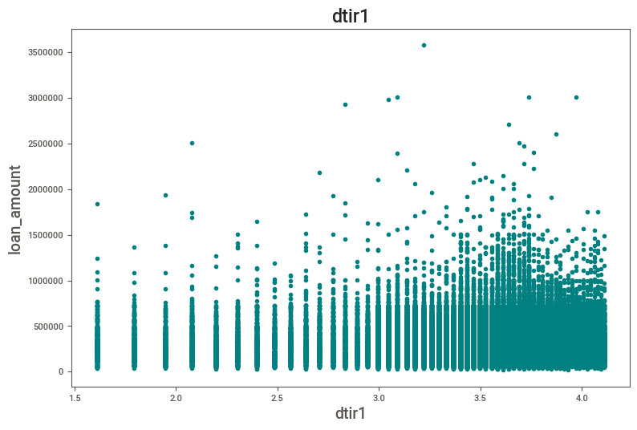

```python
#Tryign to create scatterplots with respect to the loan amount

plt.scatter(data[features], data['loan_amount'], color = 'Teal')
plt.xlabel(features)
plt.ylabel('loan_amount')
plt.title(features)
plt.show()
```

(6) Outliers

**Outliers detection ?**

Generally we use box plots using the seaborn library.

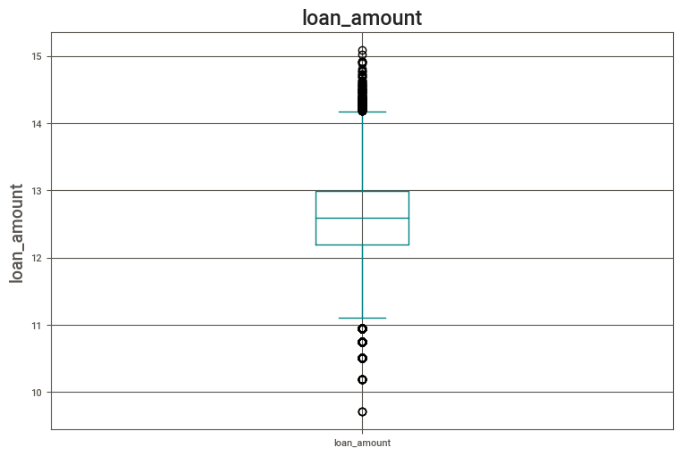

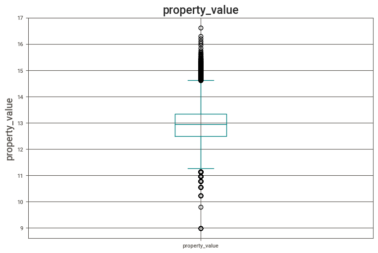

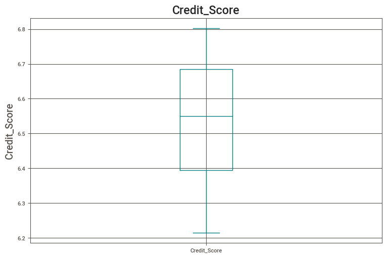

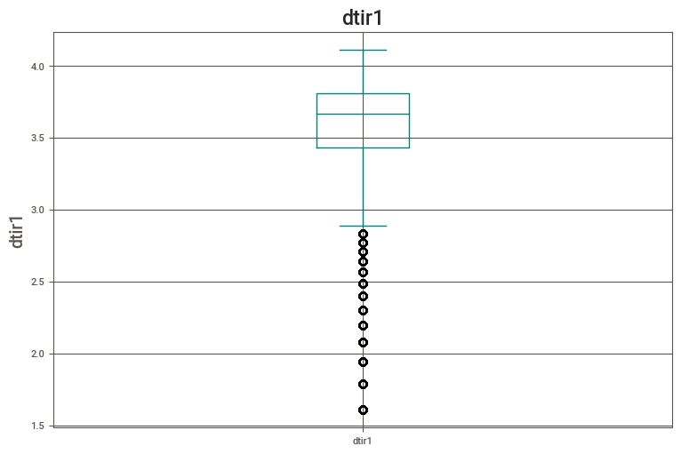

```python
for feature in continous_features:
    data = dataset.copy()
    if 0 in data[feature].unique():
        pass
    else:
        data[feature]=np.log(data[feature])
        data.boxplot(column = feature, color = 'Teal')
        plt.ylabel(feature)
        plt.title(feature)
        plt.show()
```

**Observation**

Here we have outliers for laon amount , property values, and dtir - debt to income ratio.

After the log transformation (or skipping if there were zeros), the code generates a box plot for the current feature column in the data DataFrame. The box plot is a graphical representation of the data distribution that shows the median, quartiles, and potential outliers.

Crux of the code is

the code snippet loops through each continuous feature in the dataset, applies a logarithmic transformation (skipping features that contain zeros) (#detialed expalnation above) , and then generates a box plot to visualize the distribution of the transformed data. The box plots will help you understand the central tendency, spread, and presence of outliers in each transformed feature.

This work only for Continous variables not on the categorical features.

(7) Categorical Variables

```python
categorical_features = [feature
                        for feature in dataset.columns
                        if data[feature].dtypes == 'O']
```

```python
categorical_features
```

```
['loan_limit',
 'Gender',
 'approv_in_adv',
 'loan_type',
 'loan_purpose',
 'Credit_Worthiness',
 'open_credit',
 'business_or_commercial',
 'Neg_ammortization',
 'interest_only',
 'lump_sum_payment',
 'construction_type',
 'occupancy_type',
 'Secured_by',
 'total_units',
 'credit_type',
 'co-applicant_credit_type',
 'age',
 'submission_of_application',
 'Region',
 'Security_Type']
```

```python
dataset[categorical_features].head()
```

```
Button(description='Toggle Pandas/Lux', layout=Layout(top='5px', width='140px'), style=ButtonStyle())
```

```
Output()
```

(8) Cardiability of Categorical Variables

First thing we should convertate on the categorical features is the cardinality values. How many differnet categories you have inside the categorical features. This will actually help us understand some more things and suggest how to handle each and every categorical feature.

**Categotical Features Unique Categoires**

```python
for feature in categorical_features:
    print('The feature is {} and the number of categories are {}'. format(feature, dataset[feature].unique()))
```

```
The feature is loan_limit and the number of categories are ['cf' 'ncf' 'nan']
The feature is Gender and the number of categories are ['Male' 'Sex Not Available' 'Female' 'Joint']
The feature is approv_in_adv and the number of categories are ['nopre' 'pre' 'nan']
The feature is loan_type and the number of categories are ['type1' 'type2' 'type3']
The feature is loan_purpose and the number of categories are ['p4' 'p3' 'p1' 'p2' 'nan']
The feature is Credit_Worthiness and the number of categories are ['l1' 'l2']
The feature is open_credit and the number of categories are ['nopc' 'opc']
The feature is business_or_commercial and the number of categories are ['nob/c' 'b/c']
The feature is Neg_ammortization and the number of categories are ['not_neg' 'neg_amm' 'nan']
The feature is interest_only and the number of categories are ['not_int' 'int_only']
The feature is lump_sum_payment and the number of categories are ['not_lpsm' 'lpsm']
The feature is construction_type and the number of categories are ['sb' 'mh']
The feature is occupancy_type and the number of categories are ['pr' 'sr' 'ir']
The feature is Secured_by and the number of categories are ['home' 'land']
The feature is total_units and the number of categories are ['1U' '2U' '3U' '4U']
The feature is credit_type and the number of categories are ['CIB' 'EQUI' 'EXP' 'CRIF']
The feature is co-applicant_credit_type and the number of categories are ['CIB' 'EXP']
The feature is age and the number of categories are ['35-44' '25-34' '55-64' '>74' '45-54' '65-74' '<25' 'nan']
The feature is submission_of_application and the number of categories are ['not_inst' 'to_inst' 'nan']
The feature is Region and the number of categories are ['south' 'North' 'central' 'North-East']
The feature is Security_Type and the number of categories are ['direct' 'Indriect']
```

**Caterocial Features Unique Categoires Count**

```python
for feature in categorical_features:
    print('The feature is {} and the number of categories are {}'. format(feature, len(dataset[feature].unique())))
```

```
The feature is loan_limit and the number of categories are 3
The feature is Gender and the number of categories are 4
The feature is approv_in_adv and the number of categories are 3
The feature is loan_type and the number of categories are 3
The feature is loan_purpose and the number of categories are 5
The feature is Credit_Worthiness and the number of categories are 2
The feature is open_credit and the number of categories are 2
The feature is business_or_commercial and the number of categories are 2
The feature is Neg_ammortization and the number of categories are 3
The feature is interest_only and the number of categories are 2
The feature is lump_sum_payment and the number of categories are 2
The feature is construction_type and the number of categories are 2
The feature is occupancy_type and the number of categories are 3
The feature is Secured_by and the number of categories are 2
The feature is total_units and the number of categories are 4
The feature is credit_type and the number of categories are 4
The feature is co-applicant_credit_type and the number of categories are 2
The feature is age and the number of categories are 8
The feature is submission_of_application and the number of categories are 3
The feature is Region and the number of categories are 4
The feature is Security_Type and the number of categories are 2
```

**Observation**

Here we can see that the least unique categories in the categorial festures are 2 and the highest is 8 which is in age seggregation. As majority of them are less than 5 and max at 8 , we can do one hot encoding. if needed for 8 unique categories we can try a different procedure.

(9) Relationship between Dependent and Independent features